# Clustering

Author

Rezoon Rasheed

# Context

You have salary and compensation data for a set of public employees in San Francisco in Employee_Compensation_SF.csv. This data set includes the following variables for salary in 2016:

Employee Identifier: Unique ID for each employee Organization: Organization within San Francisco’s government Department: Department within Orgniaztion Union: Union abbreviation Job Family: Type of job Job: Job Title Salary: Annual Salary (in $USD) Overtime: Overtime Salary (in $USD) Other Salaries: Other Salary, which could include contractor salary, one-time bonuses, extra work taken on, etc. (in $USD) Total Salary: Sum of three salary numbers (in $USD) Retirement: Amount paid into retirement (in $USD) Health/Dental: Amount paid into Health/Dental (in $USD) Other Benefits: Other Benefits, such as dependent care, FSA, etc. (in $USD) Total Compensation: Total Compensation, including salaries and benefits (in $USD)

## Question 1

Do the following: * Import the data. * Remove all inappropriate variables for k-means clustering * Remove any rows with missing values * Standardize your remaining variables

```r
df <- read.csv("Employee_Compensation_SF.csv") # importing dataset

# removing missing values
df <- na.omit(df)

# removing unnecessary values
df$Employee.Identifier <- NULL
df$Organization.Group <- NULL
df$Department <- NULL
df$Union <- NULL
df$Job.Family <- NULL
df$Job <- NULL

# standardizing
library(caret)
standardizer <- preProcess(df,method = c("scale","center"))
df <- predict(standardizer, df)
```

## Question 2

Use ggplot to plot the relationship between Total Salary and Total Benefits. What is the relationship between the two variables?

Answer: The plot gives us a rough idea, with the direction of the points scattered, suggesting a positive correlation between these variables. To further confirm it, a trend line is also drawn to visualize the gradient of the line to see the relation more prominently.

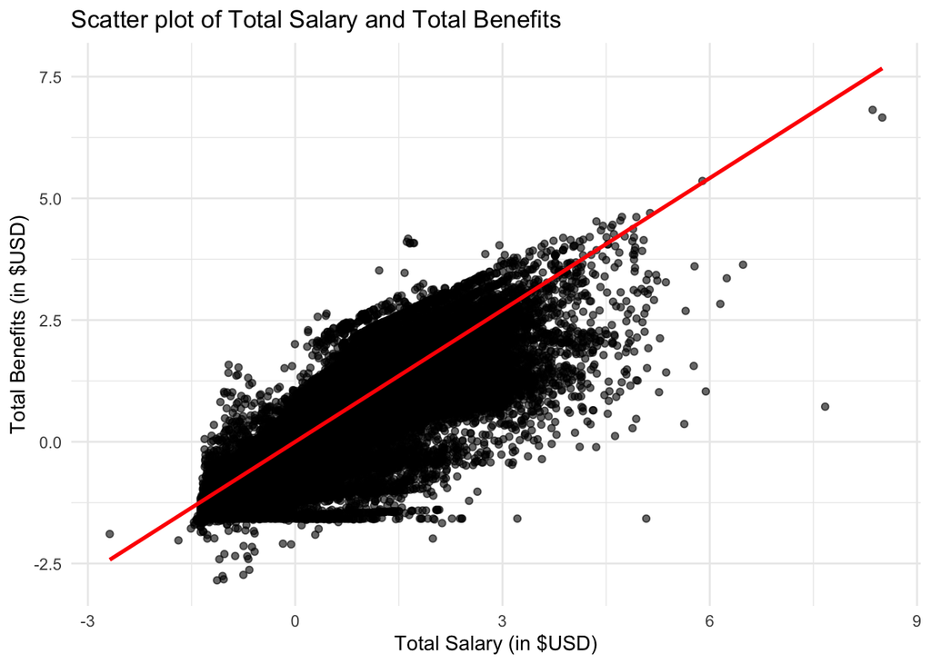

```r
library(ggplot2)
ggplot(df, aes(x = Total.Salary, y = Total.Benefits)) +
  geom_point(alpha = 0.6) +
  geom_smooth(method = "lm", color = "red", se = FALSE) +
  labs(
    title = "Scatter plot of Total Salary and Total Benefits",
    x = "Total Salary (in $USD)",
    y = "Total Benefits (in $USD)"
  ) +
  theme_minimal()
```

## Question 3

Now, we want to do k-means clustering. Before we do, create an Elbow Chart. What would you argue is the “best” number of k?

Answer: According to the elbow chart, the best number is k=3 as the elbow being formed is at almost 3. The reduction in within-cluster sum of squares becomes less significant after this point.

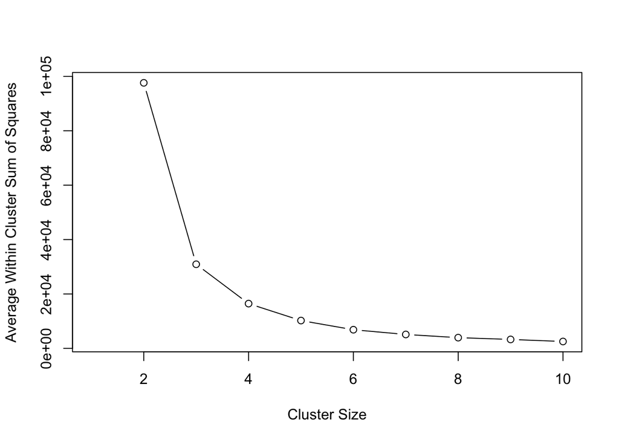

```r
df1 <- df[, c("Total.Salary", "Total.Benefits")]

source('BabsonAnalytics.R')
elbowChart(df1)
```

## Question 4

Now, run a k-means clustering. Use 4 as the number of clusters. Given the size of the data set, feel free to use nstart = 10, as this will lower computational time.

```r
set.seed(1234)
model <- kmeans(df1, centers=4, nstart=10)
```

## Question 5

Take a look at the cluster size and centers. How would you describe each of your clusters? What seems to distinguish each cluster from the others? Also, which cluster is the largest?

Answer: According to the model we ran, there are in total of 4 clusters, with the respective sizes to be 92691, 30889, 75135, 93110 which suggests that each cluster has these many observations in it. In this respective decreasing order, the size of the clusters is 4,1,3,2, with 4 being the largest and 2 being the smallest. The centers code gives us the center point of the clusters with the coordinates on x-axis = Total.Salary and y-axis = Total.Benefits. Each cluster has its center point reflected respectively, and each cluster has a different center point.

```r
model$size
```

```
[1] 92691 30889 75135 93110
```

```r
model$centers
```

```
  Total.Salary Total.Benefits
1   -1.0812325     -1.2502381
2    1.9056716      1.4516863
3    0.7084623      0.7872198
4   -0.1275275      0.1277727
```

## Question 6

Bind the clusters with the data frame. Use this new data frame to create a plot with Total Salary and Total Benefits. Make sure each cluster is a different color on your graph.

```r
df_clusters <- cbind(df, cluster = model$cluster)

# Additional Context to our question
summary(df_clusters[df_clusters$cluster==1,])
```

```
     Salary           Overtime       Other.Salaries     Total.Salary
 Min.   :-2.9552   Min.   :-0.4946   Min.   :-1.3795   Min.   :-2.6840
 1st Qu.:-1.3418   1st Qu.:-0.3978   1st Qu.:-0.4912   1st Qu.:-1.2944
 Median :-1.1865   Median :-0.3978   Median :-0.4891   Median :-1.1521
 Mean   :-1.1116   Mean   :-0.3667   Mean   :-0.3587   Mean   :-1.0812
 3rd Qu.:-0.9383   3rd Qu.:-0.3978   3rd Qu.:-0.4288   3rd Qu.:-0.9236
 Max.   : 0.9321   Max.   : 4.4639   Max.   :14.5427   Max.   : 0.8488
   Retirement      Health.Dental     Other.Benefits    Total.Benefits
 Min.   :-4.4516   Min.   :-2.4207   Min.   :-3.7914   Min.   :-2.8452
 1st Qu.:-1.3222   1st Qu.:-1.7291   1st Qu.:-1.1557   1st Qu.:-1.5026
 Median :-1.3097   Median :-1.4185   Median :-1.0110   Median :-1.3361
 Mean   :-1.1415   Mean   :-1.3013   Mean   :-0.9128   Mean   :-1.2502
 3rd Qu.:-0.9908   3rd Qu.:-0.9666   3rd Qu.:-0.7566   3rd Qu.:-1.0625
 Max.   : 1.0961   Max.   : 0.8463   Max.   : 3.4046   Max.   :-0.1555
 Total.Compensation    cluster
 Min.   :-2.5375    Min.   :1
 1st Qu.:-1.3652    1st Qu.:1
 Median :-1.2120    Median :1
 Mean   :-1.1430    Mean   :1
 3rd Qu.:-0.9655    3rd Qu.:1
 Max.   : 0.2612    Max.   :1
```

```r
summary(df_clusters[df_clusters$cluster==2,])
```

```
     Salary          Overtime       Other.Salaries     Total.Salary
 Min.   :-1.415   Min.   :-0.3978   Min.   :-0.5698   Min.   :0.6434
 1st Qu.: 1.281   1st Qu.:-0.3978   1st Qu.:-0.3694   1st Qu.:1.5000
 Median : 1.665   Median :-0.2995   Median : 0.8112   Median :1.7944
 Mean   : 1.762   Mean   : 1.1468   Mean   : 1.0561   Mean   :1.9057
 3rd Qu.: 2.060   3rd Qu.: 2.3659   3rd Qu.: 1.8877   3rd Qu.:2.1922
 Max.   :10.118   Max.   :20.1190   Max.   :44.0421   Max.   :8.4961
   Retirement     Health.Dental     Other.Benefits    Total.Benefits
 Min.   :-1.322   Min.   :-1.8207   Min.   :-3.4923   Min.   :-1.578
 1st Qu.: 1.269   1st Qu.: 0.7205   1st Qu.:-0.4696   1st Qu.: 1.026
 Median : 1.599   Median : 0.7968   Median : 1.3145   Median : 1.352
 Mean   : 1.708   Mean   : 0.8353   Mean   : 0.9468   Mean   : 1.452
 3rd Qu.: 2.009   3rd Qu.: 0.8463   3rd Qu.: 1.6204   3rd Qu.: 1.803
 Max.   : 9.414   Max.   : 1.8620   Max.   : 8.0555   Max.   : 6.818
 Total.Compensation    cluster
 Min.   :1.073      Min.   :2
 1st Qu.:1.461      1st Qu.:2
 Median :1.697      Median :2
 Mean   :1.828      Mean   :2
 3rd Qu.:2.085      3rd Qu.:2
 Max.   :8.197      Max.   :2
```

```r
summary(df_clusters[df_clusters$cluster==3,])
```

```
     Salary           Overtime       Other.Salaries      Total.Salary
 Min.   :-1.4153   Min.   :-0.4418   Min.   :-2.97650   Min.   :-0.2243
 1st Qu.: 0.4651   1st Qu.:-0.3978   1st Qu.:-0.49119   1st Qu.: 0.4278
 Median : 0.7180   Median :-0.3007   Median :-0.09571   Median : 0.6611
 Mean   : 0.7338   Mean   : 0.2290   Mean   : 0.21941   Mean   : 0.7085
 3rd Qu.: 1.0490   3rd Qu.: 0.6140   3rd Qu.: 0.65612   3rd Qu.: 0.9657
 Max.   : 2.5596   Max.   : 7.2100   Max.   :25.16951   Max.   : 2.5165
   Retirement      Health.Dental     Other.Benefits    Total.Benefits
 Min.   :-2.4320   Min.   :-1.8207   Min.   :-3.9899   Min.   :-1.6705
 1st Qu.: 0.5215   1st Qu.: 0.7148   1st Qu.: 0.4602   1st Qu.: 0.6219
 Median : 0.7269   Median : 0.7640   Median : 0.7929   Median : 0.7714
 Mean   : 0.7496   Mean   : 0.7196   Mean   : 0.6241   Mean   : 0.7872
 3rd Qu.: 0.9801   3rd Qu.: 0.8434   3rd Qu.: 1.1162   3rd Qu.: 0.9497
 Max.   : 4.6072   Max.   : 2.6429   Max.   : 7.5827   Max.   : 2.6337
 Total.Compensation    cluster
 Min.   :0.1060     Min.   :3
 1st Qu.:0.4959     1st Qu.:3
 Median :0.7042     Median :3
 Mean   :0.7410     Mean   :3
 3rd Qu.:0.9779     3rd Qu.:3
 Max.   :1.6383     Max.   :3
```

```r
summary(df_clusters[df_clusters$cluster==4,])
```

```
     Salary            Overtime       Other.Salaries      Total.Salary
 Min.   :-1.41535   Min.   :-1.5087   Min.   :-1.05214   Min.   :-1.31132
 1st Qu.:-0.26514   1st Qu.:-0.3978   1st Qu.:-0.49119   1st Qu.:-0.30818
 Median :-0.06414   Median :-0.3978   Median :-0.35499   Median :-0.12558
 Mean   :-0.07010   Mean   :-0.2002   Mean   :-0.17038   Mean   :-0.12753
 3rd Qu.: 0.12779   3rd Qu.:-0.1729   3rd Qu.:-0.07476   3rd Qu.: 0.06218
 Max.   : 2.42982   Max.   : 3.9076   Max.   :21.23351   Max.   : 1.99241
   Retirement       Health.Dental     Other.Benefits     Total.Benefits
 Min.   :-2.90097   Min.   :-1.8603   Min.   :-4.03409   Min.   :-1.98696
 1st Qu.:-0.21137   1st Qu.: 0.1921   1st Qu.:-0.10647   1st Qu.:-0.04408
 Median :-0.01789   Median : 0.7148   Median : 0.11965   Median : 0.19372
 Mean   :-0.03499   Mean   : 0.4376   Mean   : 0.09092   Mean   : 0.12777
 3rd Qu.: 0.17331   3rd Qu.: 0.7918   3rd Qu.: 0.32854   3rd Qu.: 0.35773
 Max.   : 3.02544   Max.   : 1.4468   Max.   : 5.64940   Max.   : 1.58155
 Total.Compensation    cluster
 Min.   :-0.99645   Min.   :4
 1st Qu.:-0.23497   1st Qu.:4
 Median :-0.05099   Median :4
 Mean   :-0.06659   Mean   :4
 3rd Qu.: 0.13886   3rd Qu.:4
 Max.   : 1.04269   Max.   :4
```

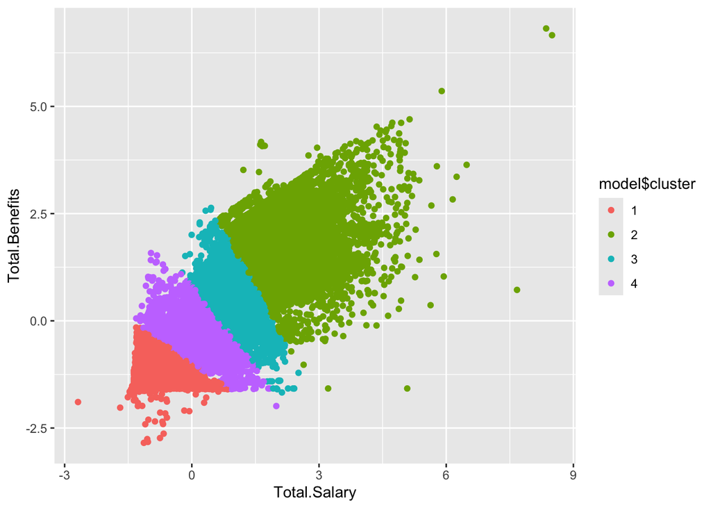

```r
model$cluster <- as.factor(model$cluster)
ggplot(df1,aes(x=Total.Salary,y=Total.Benefits,col=model$cluster)) +
  geom_point()
```

## Question 7

Now, let’s run hierarchichal clustering. Do the following: * Import the raw data into R again. * Keep only three columns: Employee Identifier, Total Salary, and Total Benefits. * Standardize your variables.

```r
rm(list = ls()) # clears global environment
#import data
dfh <- read.csv("Employee_Compensation_SF.csv")

dfh1 <- dfh[,c("Employee.Identifier","Total.Salary" ,"Total.Benefits")]

#Standardize Variables

standardizer <- preProcess(dfh1,method = c("scale","center"))
dfh1 <- predict(standardizer, dfh1)
```

## Question 8

Try to obtain the distance matrix. What happens?

Answer: The dataset is to large, thus R gives an error as its allowed memory capacity is reached for this particular visualization “vector memory limit of 16.0 Gb reached, see mem.maxVSize()”.

```r
#d <- dist(dfh1) # it needs the distance matrix to insert into the model
#d
```

## Question 9

Now keep only the first 200 rows of data with the three variables mentioned in Question 7. Obtain the distance matrix. Then Model with average linkage, single linkage, and complete linkage and plot the dendrograms. Notice that the dendrogram plots are not useful. What is the issue with the data that makes heirarchical clustering not useful?

Answer: The dendograms are not useful as the data has a large number of observations, which makes the labels to cluttered together. Thus it is really hard to make a plausible incite from the visual. hierarchical clustering is more suitable for small number of observations so that the labels are visual properly and the linkage is properly visible in the visualization.

```r
dfh1 <- dfh1[1:200,]

d <- dist(dfh1)
d
```

[output not shown]

[output cut: 6745 more lines]

[output not shown]

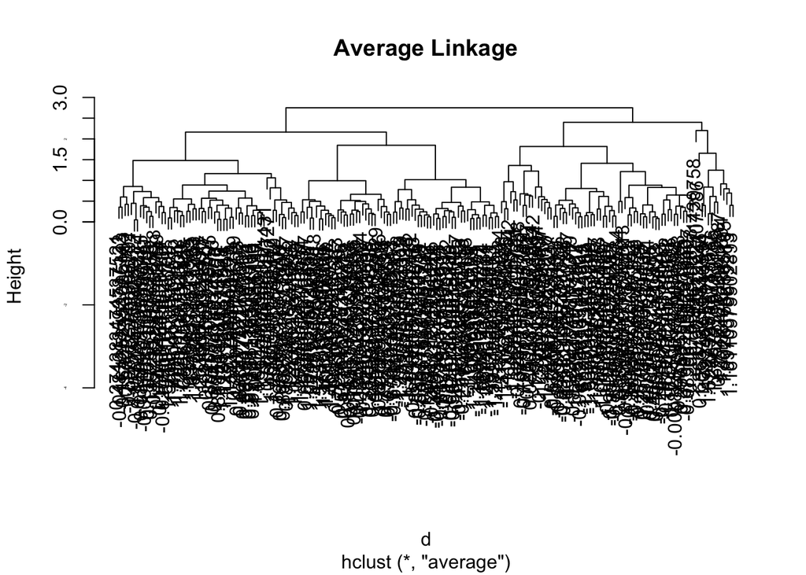

```r
# model with average linkage
model <- hclust(d, method="average") # method is the linkage function to use
plot(model, main="Average Linkage", labels=dfh1$Employee.Identifier)
axis(2,cex.axis=0.2)
```

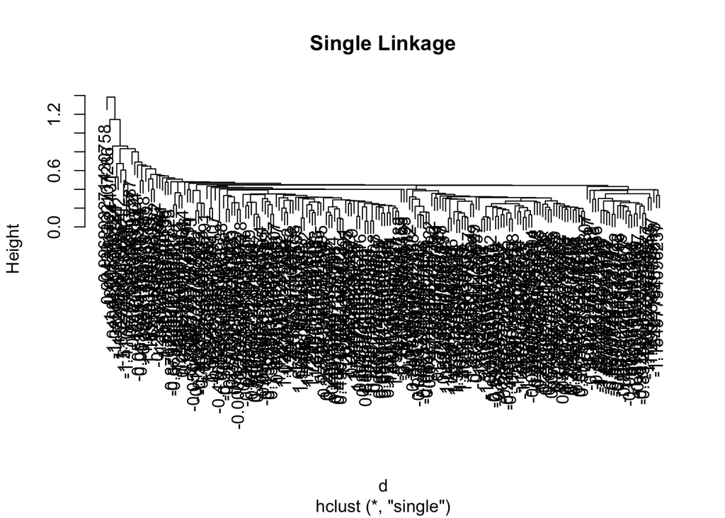

```r
# model with single linkage
model <- hclust(d, method="single")
plot(model, main="Single Linkage", labels=dfh1$Employee.Identifier)
```

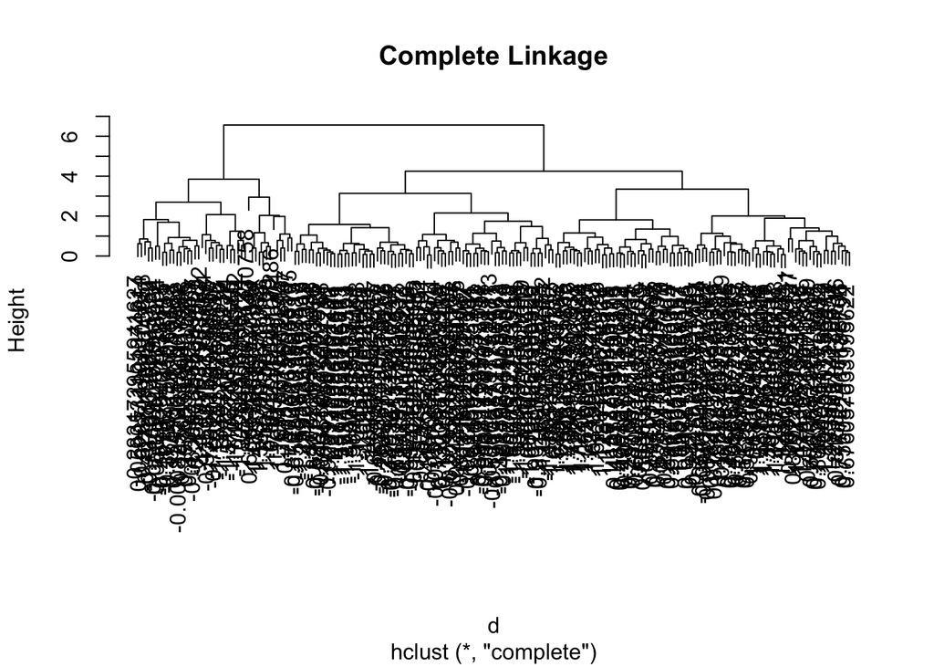

```r
# model with complete linkage
model <- hclust(d, method="complete")
plot(model,main="Complete Linkage", labels=dfh1$Employee.Identifier)
```